# Herramientas para usar con Phyloseq

```r
library(phyloseq)
```

# Introduccion

Como vimos antes de irnos phyloseq nos ayuda a integrar todos nuestros datos en un objeto para poder analizarlo. La clase de hoy vamos a ver como phyloseq nos deja modificar estos objetos para visualizarlos mejor y seguir con los diferentes tipo de analisis usando los datos de vid.

```r
load("Vid_S85.RData") # siempre se empieza con el objeto de phyloseq
```

# Las primeras visualizaciones de nuestros datos

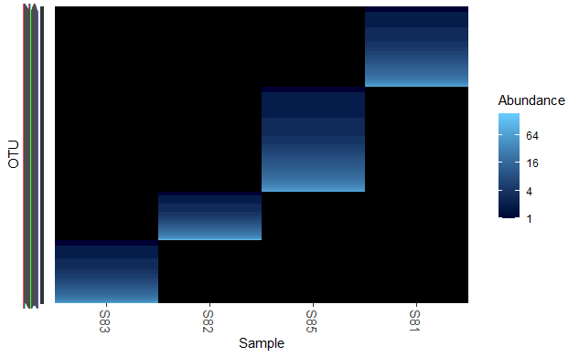

```r
plot_heatmap(vid_bio, taxa.label = "Phylum")
```

Si bien con estos datos ya podemos realizar grafico que nos acercan mas al analisis el hecho es de que siempre es comvenenientre pre-procesar los datos antes de cualquier grafico. Para ello phyloseq nos ofrece varias herramientas:

# Preproccesamiento de datos

## Filtraado

### Prune vs subset

```r
# usando datos de la tabla de taxa
Actino <- subset_taxa(vid_bio, # objeto
                      Phylum=="Actinobacteriota") # la condicion puede ser cualquier nivel de la jerarquia taxonomica

# usando abundancias quitar muestras
Actino <- prune_samples(sample_sums(Actino)>=50, # condicion que las que sean menor a 50 me las va a quitar
                        Actino) # objeto
```

# Union o merge

```r
# Uniendo muestras
Tratamientos <- merge_samples(vid_bio, # objeto
                              "Tratamiento") # condicion de metadatos
```

### Ejercicio unir las muestras de todos

```r
vid_bio$sam_data$Suelo[is.na(vid_bio@sam_data$Suelo)] <- "Salino"
```

```
Error in `*tmp*`$sam_data : $ operator not defined for this S4 class
```

```r
load("phylo_soil.RData")
```

## Abundancia relativa

DADA2 nos da abundancias absolutas las cuales pasamos a nuestro objeto de phyloseq. La abundancia abdoluta es el conteo TOTAL de las especies e individuos dentro de cada especie

La abundancia relativa en cambio normaliza nuestras muestras para poder compararlas entre si. Para ello usa proporciones siendo 1 el 100% de nuestro conteo por muestras. De esta manera podemos comparar la composicion de nuestras muestras aunque no tengamos valores totales o absolutos iguales.

# Reexploramos graficos

```r
# 1. Graficos
Top_phyla <- tax_glom(Psoil_rel,taxrank = "Phylum", NArm = FALSE)
Top_phyla <- prune_taxa(names(sort(taxa_sums(Top_phyla), TRUE)[1:10]), #cond
                        Top_phyla) # objeto que voy a modificar

plot_bar(Top_phyla, fill = "Phylum")
plot_heatmap(Top_phyla, taxa.label = "Phylum")
```

[output not shown]